# RecsysChallenge

Wesley Nunes

May 13, 2016

# RecSys Challenge 2016:

> Problema 6/Checkpoint 1

### Wesley Nunes Marques Torres

A competição objeto deste lab trata da recomendação de ofertas de trabalho na plataforma Xing. A competição está aberta (site aqui ) e dura até meados de Junho. Nesta etapa nós iremos imergir nos dados para entendêlos. É nela que se busca entender o “comportamento” das variáveis (suas amplitudes, distribuições, valores atípicos, e muito mais. Formularemos perguntas que ajudarão a entender os dados e tiraremos valor das respostas para a sua estratégia.

> Dados Utilizados

Temos 5 conjuntos de dados. São eles:

- users_v01 Informações sobre os usuários;
- Regions Informações sobre as regiões;
- items_v01 Informações sobre ofertas de emprego;
- interations_v01 Informações sobre a interaçao dos usuários com empregos;
- impressions A frequência em que uma oferta de emprego foi mostrada para um usuário por semana

> Users

```r
str(users)
```

```
## 'data.frame':    2935049 obs. of  12 variables:
##  $ id                         : int  4 7 7 9 9 9 9 13 19 23 ...
##  $ jobroles                   : int  2424638 3287640 524375 3418410 3418410 3418410 3418410 3079492 3378061 165098 ...
##  $ career_level               : Factor w/ 8 levels "0","1","2","3",..: 4 1 1 3 3 3 3 8 5 4 ...
##  $ discipline_id              : int  0 3 3 0 0 0 0 0 0 0 ...
##  $ industry_id                : int  8 8 8 0 0 0 0 0 0 1 ...
##  $ country                    : Factor w/ 5 levels "at","ch","de",..: 3 3 3 3 3 3 3 3 3 3 ...
##  $ region                     : Factor w/ 18 levels "0","1","10","11",..: 3 2 2 1 1 1 1 10 1 2 ...
##  $ experience_n_entries_class : Factor w/ 4 levels "1","2","3","NULL": 2 1 1 3 3 3 3 1 2 3 ...
##  $ experience_years_experience: Factor w/ 9 levels "0","1","2","3",..: 6 1 1 3 3 3 3 3 5 8 ...
##  $ experience_years_in_current: Factor w/ 9 levels "0","1","2","3",..: 5 1 1 2 2 2 2 3 2 7 ...
##  $ edu_degree                 : Factor w/ 5 levels "0","1","2","3",..: 1 1 1 2 2 2 2 1 1 1 ...
##  $ edu_fieldofstudies         : int  NA NA NA 2 8 5 3 2 NA 3 ...
```

- id: id do usuário;
- jobroles: id do emprego
- career_level: O nível de carreira do usuário
- discipline_id: id do segmento da empresa em que atua
- industry_id : id da área em que a empresa atua
- country: País em que o usuário atualmente trabalha
- region :Região do país em que atua
- experience_n_entries_class: Número de experiências de trabalho
- experience_year_experience:Anos de experiência de trabalho estimados
- experience_years_in_current:Número de anos que o usuário está trabalhando no emprego atual
- edu_degree: Nível de escolaridade estimado
- edu_fieldofstudies: id da área de conhecimento que o usuário estudou.

> Regions

```r
str(region)
```

```
## 'DataFrame': 2 variables:
##  $ C0: chr "ID" "0" "1" "2" "3" "4"
##  $ C1: chr "Name" "not specified" "Baden-Württemberg" "Bavaria" "Berlin" "Brandenburg"
```

Dataset para mapeamento das regiões

> items

```r
str(items)
```

```
## 'DataFrame': 13 variables:
##  $ C0 : chr "id" "19" "19" "19" "19" "19"
##  $ C1 : chr "title" "4298526" "4298526" "4298526" "4298526" "4298526"
##  $ C2 : chr "career_level" "3" "3" "3" "3" "3"
##  $ C3 : chr "discipline_id" "18" "18" "18" "18" "18"
##  $ C4 : chr "industry_id" "15" "15" "15" "15" "15"
##  $ C5 : chr "country" "ch" "ch" "ch" "ch" "ch"
##  $ C6 : chr "region" "0" "0" "0" "0" "0"
##  $ C7 : chr "latitude" "47.4" "47.4" "47.4" "47.4" "47.4"
##  $ C8 : chr "longitude" "8.5" "8.5" "8.5" "8.5" "8.5"
##  $ C9 : chr "employment" "1" "1" "1" "1" "1"
##  $ C10: chr "tags" "1471052" "2072458" "2512557" "1077976" "2643380"
##  $ C11: chr "created_at" "1438466400" "1438466400" "1438466400" "1438466400" "1438466400"
##  $ C12: chr "active_during_test" "0" "0" "0" "0" "0"
```

- id: id do item
- title: Titulo da oferta de emprego, numericamente
- career_level, discipline_id, industry_id, country, region: Iguais aos de User, mas se tratando de empregos
- Latitude ,longitude: Informações de latitude e longitude da localização da empresa
- employment: Regime de carga?horária
- tags :Tags relacionadas à oferta de emprego, numericamente
- created_at: Data de criaçao da oferta
- active_during_test: Validade da oferta

> Interações

```r
str(interactions_data)
```

```
## 'DataFrame': 4 variables:
##  $ C0: chr "user_id" "7" "9" "9" "9" "9"
##  $ C1: chr "item_id" "1006839" "944146" "944146" "944146" "1053485"
##  $ C2: chr "interaction_type" "1" "3" "1" "1" "1"
##  $ C3: chr "week" "35" "41" "41" "41" "41"
```

> Impressions

```r
str(impressions)
```

```
## 'DataFrame': 5 variables:
##  $ C0: chr "user_id" "1" "2" "2" "2" "2"
##  $ C1: chr "week" "42" "36" "36" "36" "36"
##  $ C2: chr "item_id" "740352" "1040247" "1209670" "1238402" "150798"
##  $ C3: chr "frequency" "2" "2" "4" "2" "4"
##  $ C4: chr "cumulative_count" "2" "2" "4" "2" "4"
```

> Algumas observações

Podemos agora realizar algumas realções. COm isso, queremos avaliar a relação entre a qualificação profissional com os cargos dos usuários

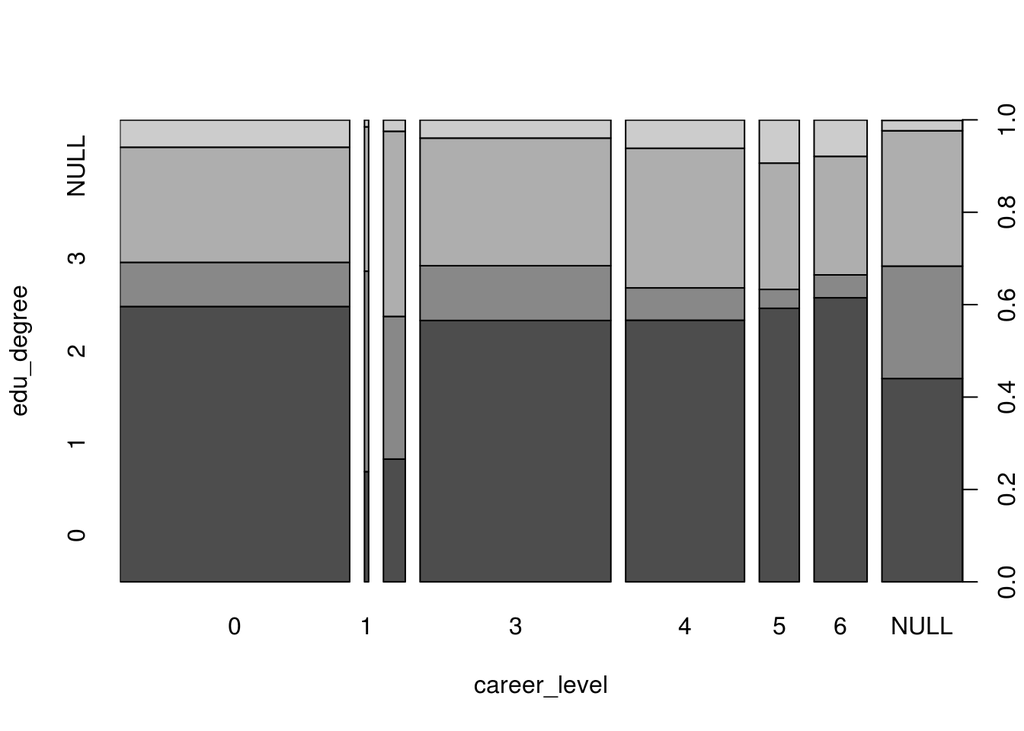

```r
plot(users$career_level, users$edu_degree, xlab = "career_level", ylab = "edu_degree")
```

Como podemos perceber o números de Unknown(0) juntamente com NULL está ocupando uma garnde fatia dos dados que já perdemos um pouco na nossa informação. Vemos que os executivos(5) são os que mais possuem um nível educacional maior. Isso nos confirma uma premissa natural no meio que quanto mais qualificado, melhor o cargo. Temos também que os cargos de projeto como Professional/Experienced(3) e Manager(4) são a maioria e que grande massa possuem no máximo um mestrado(2).

Será que existe um padrão de cargos nas regiões?

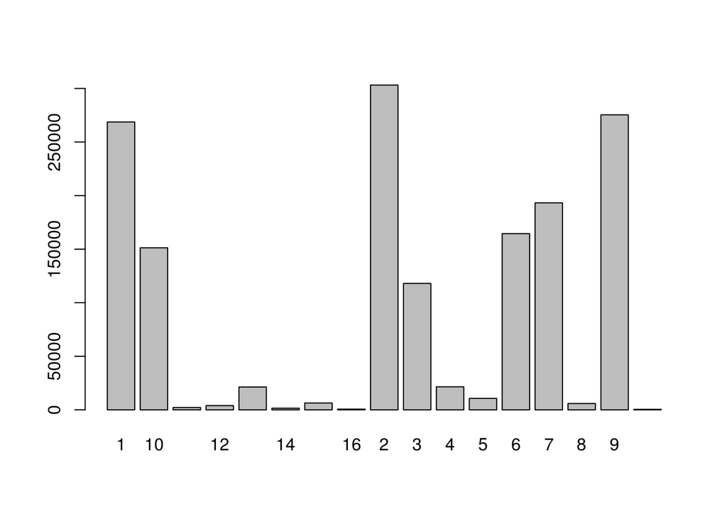

```r
user_filter <- filter(users, users$region != c(0,NULL)) %>% droplevels()

plot(user_filter$region)
```

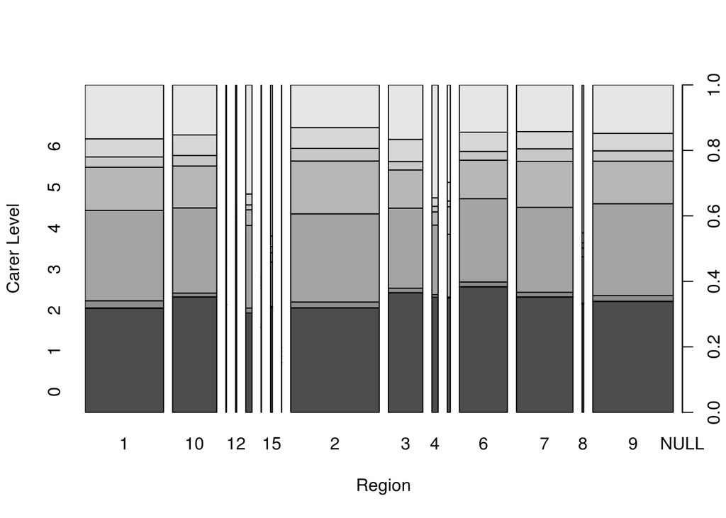

```r
plot(user_filter$region, user_filter$career_level, xlab = "Region", ylab = "Carer Level")
```